# Egzaminas

Deivydas Sinkevičius

2017 m sausis 20 d

## Užduotis1

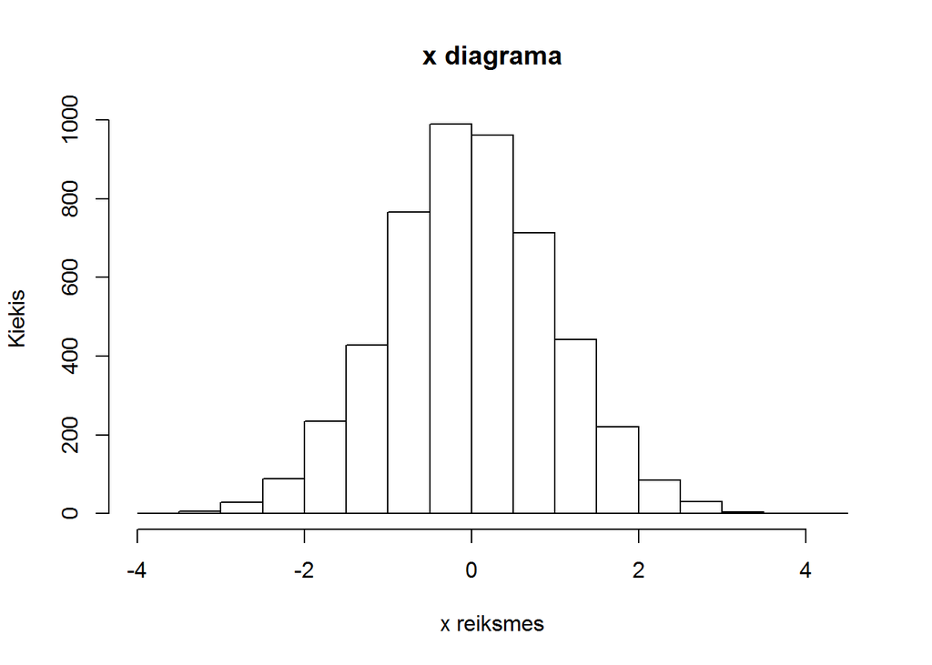

```r
set.seed(1234567890)
x <- rnorm(5000)
hist(x,main = 'x diagrama', xlab = 'x reiksmes', ylab = 'Kiekis')
```

a) Suraskite x vidukio ir standartinio nuokrypio įverčius.

```r
vid = mean(x) # Randame vidurki
sd = sd(x) # Randame standartini nuokrypi
```

```r
a = vid-3*sd # Randame intervalo pradzia
b = vid+3*sd # Randame intervalo pabaiga
int = a:b # Sudarome intervala
xa <- which(x<a) # x kurie nepatenka yra mazesni uz intervalo pradzia
xb <- which(x>b) # x kurie yra didesni uz intervalo pabaiga
xb # Indeksai reiksmiu, nepakliunanciu i intervala
```

```
## [1] 2329 2609 3351 3835 3924
```

```r
isskir <- x[xb] # Randamos isskirtys
```

3. Pašalinkite rastas išskirtis iš x vektorius ir nubrėžkite atnaujinto x histogramą.

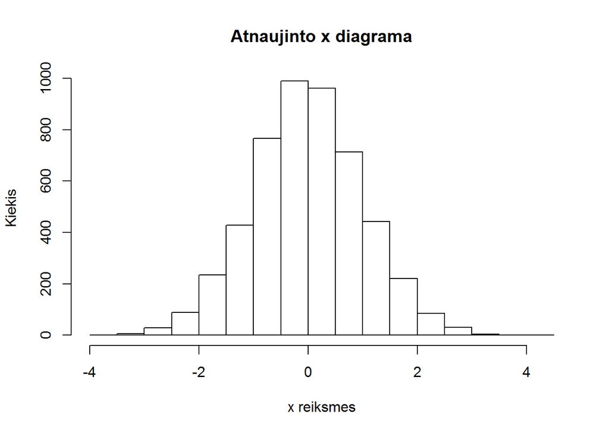

```r
xn <- setdiff(x, xb) #Pasalinamos nereikalingos reiksmes
hist(xn, main = 'Atnaujinto x diagrama', xlab = 'x reiksmes', ylab = 'Kiekis')
```

## Užduotis2

2. Sugeneruokite X imtį (N=10000) pagal pateiktą X apibrėžimą

```r
X1 = rnorm(10000, 3, 4)
X2 = rnorm(10000, -1, 9)
X = X1 + X2
```

```r
X1 = rnorm(10000, 3, 4)
X2 = rnorm(10000, -1, 9)
X = X1 + X2
prob
```

[output not shown]

## Užduotis3

1. Duomenų apžvalga ir paruošimas. Šioje dalyje jums reikia susipažinti su duomenimis ir paruošti duomenis tolimesnei analizei.
1. Nuskaitykite duomenų masyvą. Jeigu įmanoma, nekoreguokite originalaus failo.

```r
data <- read.csv("https://raw.githubusercontent.com/1vbutkus/Econometrics1/master/Egzaminas/data.csv", header = TRUE,sep=";",dec=".",skip=7)
head(data)
```

```
##     kaina     rida  amzius galia markesKodas
## 1 12770.1 164110.9      11    55          qt
## 2 15180.7 673467.4      12    55          ky
## 3 17591.9 494773.3      15    75          ky
## 4   19854 360467.9       2    65          qt
## 5    5574 601594.7 MISSING    55          bm
## 6 22996.3 377599.3       5    65          ky
```

2. Paruoškite duomenis naudojimui. Jūs turite užtikrinti, kad:

Neliko įrašų su trūkstamomis reikšmėmis - jeigu šalinote įrašus, tai būtinai raportuokite kiek įrašų pašalinta ir kiek liko. Duomenų masyve nėra kažkokių klaidų (pvz. negalimos reikšmės, neteisingas duomenų tipas, t.t.). Patartina patikrinti visų duomenų tipus, nes kartais nuskaitymo procedūra suinterpretuoja duoenis ne taip kaip tikimasi.

```r
sapply(data, class)
```

```
##       kaina        rida      amzius       galia markesKodas
##    "factor"   "numeric"    "factor"   "integer"    "factor"
```

```r
data$kaina <- as.numeric(data$kaina)
data$amzius <- as.numeric(data$amzius)
data$galia <- as.numeric(data$galia)
```

c)Pateikite trumpą kintamųjų apžvalgą. Naudokite tik tuos duomenis (ir kintamuosius), kuriuos planuojate taikyti tyrimui, t.y. jei reikėjo ką nors modifikuoti, tai senųjų reikšmių naudoti nebereikia. Šiai apžvalgai užtenka informacijos, kurią pateikia funkcijos plot, summary ir cor.

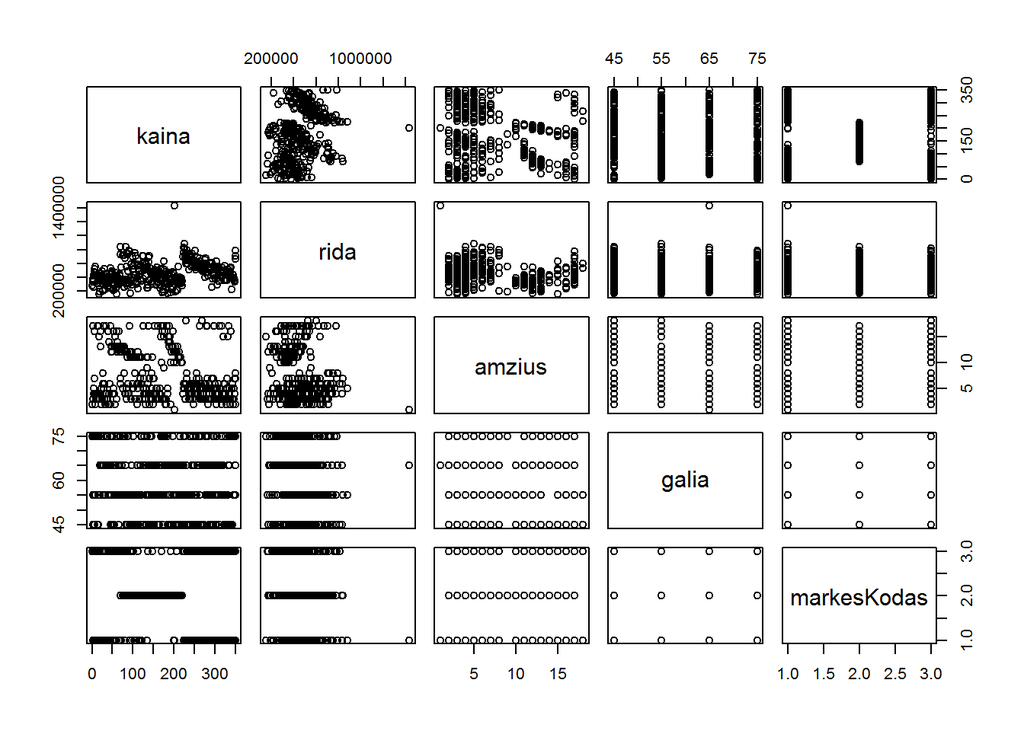

```r
plot(data)
```

```r
summary(data)
```

```
##      kaina             rida             amzius           galia
##  Min.   :  1.00   Min.   : 154691   Min.   : 1.000   Min.   :45.00
##  1st Qu.: 88.75   1st Qu.: 358160   1st Qu.: 4.000   1st Qu.:55.00
##  Median :176.50   Median : 449697   Median : 5.000   Median :55.00
##  Mean   :176.49   Mean   : 463755   Mean   : 7.403   Mean   :59.03
##  3rd Qu.:264.25   3rd Qu.: 553075   3rd Qu.:11.250   3rd Qu.:65.00
##  Max.   :350.00   Max.   :1436011   Max.   :18.000   Max.   :75.00
##  markesKodas
##  bm:120
##  ky:118
##  qt:114
##
##
##
```

Duomenų masyvą suskaidykite į du atskirus ir nesikertančius masyvus. Didesnį masyvą turi sudaryti apie 80 proc. turimų stebėjimų. Šį masyvą vadinsime trainSet. Mažesnį masyvą turi sudaryti likę įrašai. Šį masyvą vadinsime testSet. Duomenų suskaidymas turi būti atsitiktinis. Gali būti naudingos šios funkcijos:sample, setdiff, %in%.

```r
trainSet_ind = sample(1:nrow(data), round(nrow(data)*0.8)) # Atsitiktinių indeksų aibė (80% duomenų)
testSet_ind = setdiff(1:nrow(data), trainSet_ind)          # Atsitiktinių indeksų aibė, (20% duomenų)
trainSet = data[trainSet_ind,]                             # 80%
testSet = data[testSet_ind,]
```

2. Tiesinio modelio sudarymas. Modelio sudarymui naudokite trainSet masyvą.
1. Įvertinkite tiesinį modelių, kuriame prognozuojamas kintamasis būtų kaina. Ji turi tiesiškai priklausyti nuo kitų kintamųjų.

```r
head(trainSet)
```

```
##     kaina     rida amzius galia markesKodas
## 247   166 249482.1      4    55          ky
## 281     2 380920.8     17    45          bm
## 66    271 487575.4      5    65          bm
## 185   131 422355.4      4    65          ky
## 250   347 390825.4      5    75          qt
## 208   275 658679.2      3    65          qt
```

```r
kaina = trainSet$kaina
rida = trainSet$rida
amzius = trainSet$amzius
galia = trainSet$galia
markesKodas = trainSet$markesKodas
mod = lm (kaina ~ rida + amzius + galia + markesKodas)
summary(mod)
```

```
##
## Call:
## lm(formula = kaina ~ rida + amzius + galia + markesKodas)
##
## Residuals:
##      Min       1Q   Median       3Q      Max
## -196.544  -80.490    4.127   76.265  180.601
##
## Coefficients:
##                 Estimate Std. Error t value Pr(>|t|)
## (Intercept)    1.851e+02  4.042e+01   4.580 7.06e-06 ***
## rida           1.367e-04  3.639e-05   3.756  0.00021 ***
## amzius        -2.885e+00  1.204e+00  -2.397  0.01720 *
## galia         -7.719e-01  5.380e-01  -1.435  0.15247
## markesKodasky -3.186e+01  1.381e+01  -2.308  0.02175 *
## markesKodasqt  9.518e+00  1.421e+01   0.670  0.50351
## ---
## Signif. codes:  0 '***' 0.001 '**' 0.01 '*' 0.05 '.' 0.1 ' ' 1
##
## Residual standard error: 94.88 on 276 degrees of freedom
## Multiple R-squared:  0.1103, Adjusted R-squared:  0.09422
## F-statistic: 6.846 on 5 and 276 DF,  p-value: 4.856e-06
```

```r
fit = lm(kaina ~ rida + amzius + galia)
```

3. Patikrinkite ar modelio paklaidas galime laikyti normaliomis.

```r
newy = predict(mod, trainSet)
sd(newy - kaina)
```

```
## [1] 94.03655
```

```r
summary(mod)$sigma
```

```
## [1] 94.8845
```

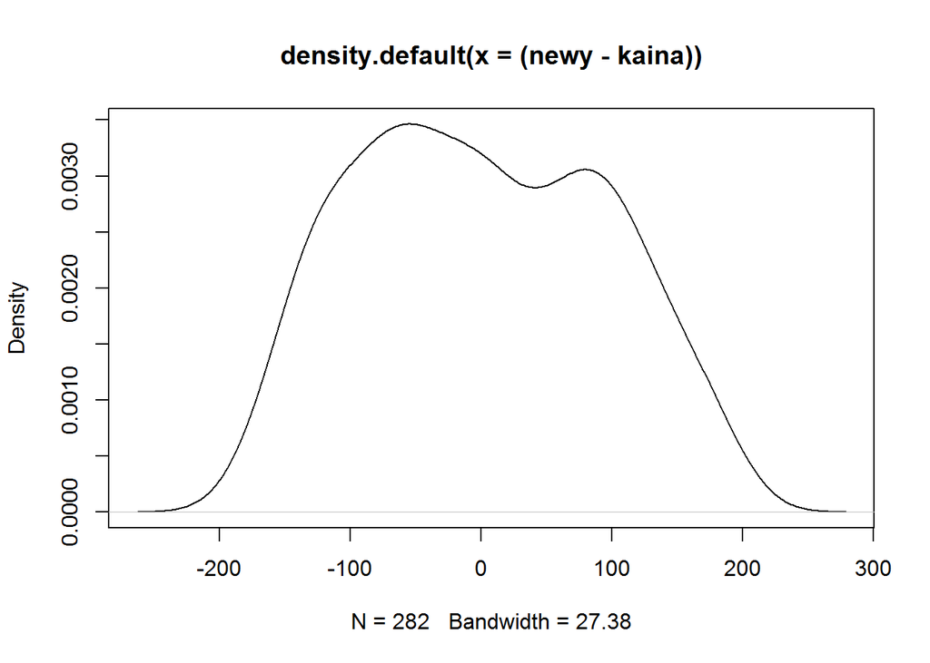

```r
plot(density((newy - kaina)))
```

```r
shapiro.test(fit$res) # Tikrina, ar paklaidos turi normalųjį skirstinį
```

```
##
##  Shapiro-Wilk normality test
##
## data:  fit$res
## W = 0.96804, p-value = 6.462e-06
```

3. Modelių palyginimas ir prognozė.

```r
RMSE = function(duomenys){
  return(sqrt((1/n)*(sum(duomenys$kaina - prognoze)^2)))
}
```